# lecture_25a_html_convert

**Submitting Final Project as HMTL format**

- You will submit your notebook for the final project in **both** .ipynb and .html formats.
- Converting a Jupyter notebook to HTML format renders it in a "published" format that can be read by someone else as a report.
- You can follow the steps depicted below to convert any notebook to HTML.
- **Make sure all useful/informative code output is visible before converting to HTML**
- **Make sure all non-useful/uninformative code output is removed before converting to HTML**

**Steps for converting to HTML**

Step 1: Click the 3 dots in the toolbar for "More Actions"

[figure not shown]

Step 2: Choose "export"

[figure not shown]

Step 3: Select "HTML" from the dropdown window

[figure not shown]

Step 4: Select "Export" in the pop-up window.

[figure not shown]

We'll demonstrate with this notebook.

**My project**

- Text in Markdown cells help the reader follow what is happening in the notebook.
- Giving a big picture overview of what the code does is very helpful to include in your Markdown.
- You can always supplement it with comments in the actual code cell when you want to describe the behavior of a single line, or give more detail

Below, I read in the dataset "features.csv", which contains data for different make/models of cars. After reading it in, we generate a table of basic descriptive statistics (rounded to two decimal digits)

```python
import pandas as pd

df_cars = pd.read_csv("data/features.csv")

summary = df_cars.describe().round(2)

display(summary)
```

|  | mpg | cylinders | displacement | weight | acceleration |
| --- | --- | --- | --- | --- | --- |
| count | 398.00 | 398.00 | 398.00 | 398.00 | 398.00 |
| mean | 23.51 | 5.45 | 193.43 | 2970.42 | 15.57 |
| std | 7.82 | 1.70 | 104.27 | 846.84 | 2.76 |
| min | 9.00 | 3.00 | 68.00 | 1613.00 | 8.00 |
| 25% | 17.50 | 4.00 | 104.25 | 2223.75 | 13.82 |
| 50% | 23.00 | 4.00 | 148.50 | 2803.50 | 15.50 |
| 75% | 29.00 | 8.00 | 262.00 | 3608.00 | 17.18 |
| max | 46.60 | 8.00 | 455.00 | 5140.00 | 24.80 |

When deciding between "print" and "display", check how its rendered in the HTML before making the decision

```python
print(summary)
```

```
          mpg  cylinders  displacement   weight  acceleration
count  398.00     398.00        398.00   398.00        398.00
mean    23.51       5.45        193.43  2970.42         15.57
std      7.82       1.70        104.27   846.84          2.76
min      9.00       3.00         68.00  1613.00          8.00
25%     17.50       4.00        104.25  2223.75         13.82
50%     23.00       4.00        148.50  2803.50         15.50
75%     29.00       8.00        262.00  3608.00         17.18
max     46.60       8.00        455.00  5140.00         24.80
```

- Next, we generate a scatterplot of car weight vs. car mileage.
- It is a good idea to motivate why you are doing this. For example, you might briefly explain that it is a reasonable hypothesis that heavier cars have worse gas mileage.

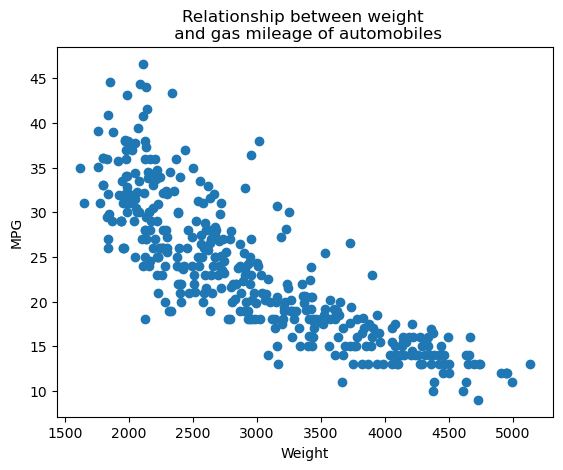

```python
import matplotlib.pyplot as plt

plt.scatter(x = df_cars['weight'], y = df_cars['mpg'])
plt.xlabel("Weight")
plt.ylabel("MPG")
plt.title("Relationship between weight \n and gas mileage of automobiles")
plt.show()
```

- Use `plt.show()` (with the parentheses!) to avoid pointless text being shown to the reader:

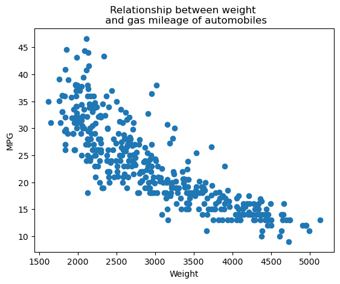

```python
plt.scatter(x = df_cars['weight'], y = df_cars['mpg'])
plt.xlabel("Weight")
plt.ylabel("MPG")
plt.title("Relationship between weight \n and gas mileage of automobiles")
```

- Try to resolve or suppress *warning* messages.
- They look really ugly after converting to HTML.
- There should be NO *error* messages at all!

```python
df_fifa_15 = pd.read_csv('data/players_15.csv')
```

```
/var/folders/6y/3fspf4yj07l356wmy5nqj83h0000gq/T/ipykernel_74729/1824888011.py:1: DtypeWarning: Columns (104) have mixed types. Specify dtype option on import or set low_memory=False.
  df_fifa_15 = pd.read_csv('data/players_15.csv')
```

- Delete code cells that display unnecessary/uninformative output.
- I don't need to see long outputs from the help command!

```python
help(pd.read_csv)
```

[output not shown]

[output cut: 383 more lines]

[output not shown]